# ImmunoGenetics assignment

Antoine Cordoin and Gaspard de Tournemire

Due date: June 3rd, 2020

# Goal

We’re doing an internship in an immunology lab working with mice. The lab developed a QTL panel (a dense genetic map) for LEWIS and BN lines and the PI (Principal Investigator) asked the previous intern to do a QTL analysis for IgG1 production. Unfortunately, the intern was super sloppy and his digital lab book is very messy with bits of code and comments. The PI tasked us to revisit and document the analysis, to produce a nicer report.

# Data

## Genetic data

For the Quantitative Trait Locus panel, our lab has gathered genetic data on 200 mice organisms. The data concerns the occurrence of 24 distinct genetic markers on chromosomes 1 and 2 (labeled $\scriptsize\text{Mar_Chr[chromosome number]_[marker number]}$ in our data) and the level of expression of G1 Immunoglobulin (IgG1) in each organism. To begin with, we’ve organized our data in a neat table, structured as follows :
$$\begin{array} {|c|c|}\hline \text{Organisms} & \text{Mar_Chr1_1} & {[}...{]} & \text{Mar_Chr2_15} & \text{IgG1 (cM)} \\ \hline 1 & 0 & {[}...{]} & 1 & 9.765525 \\ \hline {[}...{]} & {[}...{]} & {[}...{]} & {[}...{]} & {[}...{]} \\ \hline 200 & 0 & {[}...{]} & 0 & 10.136056 \\ \hline \end{array}$$
What’s interesting for us to study is the effect of these genetic markers on the expressed phenotype (IgG1 levels).

## Genetic map

The genetic marker we studied can be situated on chromosomes via a genetic map. Thus, for each marker, we have a particular location on its chromosome in our database, as is visualized for the first and last markers in the following table :

|  | Marker | Location | Chromosome |
| --- | --- | --- | --- |
| 1 | Mar_Chr1_1 | 0 | Chr1 |
| 2 | Mar_Chr1_2 | 13 | Chr1 |
| 23 | Mar_Chr2_14 | 110 | Chr2 |
| 24 | Mar_Chr2_15 | 150 | Chr2 |

We can easily find out from this database simple informations, such as the distribution of markers on the two chromosomes :

```
## Chr1 Chr2
##    9   15
```

The mean distance between two marker loci :

```
##     Chr1     Chr2
## 12.50000 10.71429
```

The range of distances between marker loci :

```
## $Chr1
## [1]  1 30
##
## $Chr2
## [1]  1 40
```

and finally the section of the chromosomes where all the markers are found, being the maximum and minimum locations of markers :

```
## $Chr1
## [1]   0 100
##
## $Chr2
## [1]   0 150
```

# Analysis on chromosome 1

In order to study the correlation of the various markers with the quantitative trait we’re studying (IgG1 expression), we’ll calculate a score based on the likelihood of observing an effect of the markers on the phenotype, the Log of Odd Ratios (LOD) score. This score is calculated as : $LOD = \log_{10}\left( \frac{L_{H_1}(\hat{\mu}_0, \hat{\mu}_1, \hat{\sigma})}{L_{H_0}(\hat{\mu}, \hat{\sigma})} \right)$, $L_{H_1}$ being the likelihood of correlation and $L_{H_0}$ the likelihood of complete independence.

Thus from the previous data, we can get the LOD scores for all the 9 markers situated on chromosome 1 :

```
## LOD score for Mar_Chr1_1: 1.93329207299265
## LOD score for Mar_Chr1_2: 3.52999775017893
## LOD score for Mar_Chr1_3: 1.92601176710798
## LOD score for Mar_Chr1_4: 1.91500541917862
## LOD score for Mar_Chr1_5: 0.802155580811186
## LOD score for Mar_Chr1_6: 0.714998623535135
## LOD score for Mar_Chr1_7: 0.264438414961971
## LOD score for Mar_Chr1_8: 0.264438414961971
## LOD score for Mar_Chr1_9: 0.238741316202608
```

We can then plot the distribution of LOD Scores on the chromosome, to get a better idea of the situation of the QTL :

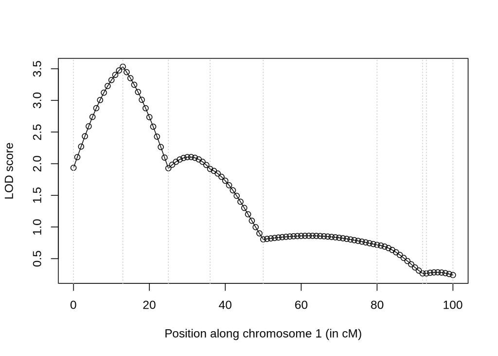

# Analysis on chromosome 2 (DIY)

We’ll use the same techniques to analyze the second chromosome’s 15 markers :

```
## LOD score for Mar_Chr2_1: 1.96039250430153
## LOD score for Mar_Chr2_2: 2.10027755443542
## LOD score for Mar_Chr2_3: 2.38041121476473
## LOD score for Mar_Chr2_4: 2.31536336198894
## LOD score for Mar_Chr2_5: 0.506244721401569
## LOD score for Mar_Chr2_6: 0.00407300041041897
## LOD score for Mar_Chr2_7: 0.431051709367631
## LOD score for Mar_Chr2_8: 0.682246260258248
## LOD score for Mar_Chr2_9: 2.75341116816065
## LOD score for Mar_Chr2_10: 2.95346434316894
## LOD score for Mar_Chr2_11: 2.01996823204963
## LOD score for Mar_Chr2_12: 1.95729588923377
## LOD score for Mar_Chr2_13: 0.956096959776347
## LOD score for Mar_Chr2_14: 0.780253943070914
## LOD score for Mar_Chr2_15: 0.780253943070914
```

And plot the found LOD scores to situate the QTL on this other chromosome :

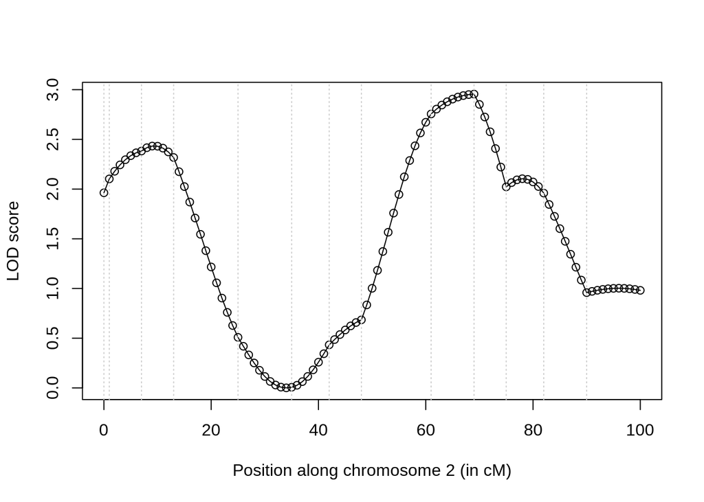

On this chromosome, it appears there are two notable contenders for potential QTL, from markers 2 to 4 and 9 to 11.

# Conclusion

From our genetic data set on LEWIS and BN mice, we set out to find a Quantitative Trait Locus associated with G1 Immunoglobulin production.

With this aim, we studied genetic markers, DNA sequences whose locations are known on the two studied chromosomes (Chr1 and Chr2). By calculating Log of Odds Ratio scores for each markers, in order to find out the markers most correlated with higher IgG1 levels, we could narrow down potential QTL on both chromosomes.

# Perspective

For simplicity, we’ve considered our organisms to be haploid, which is not too fallacious, considering BN and LEW mice are controlled inbred lineages, and practically homozygotes. To adapt our studies to a diploid consideration, we have to take into account the dominance relationships of our studied alleles. Therefore, we’d have to measure LOD scores for the markers on both homologous chromosomes, and clear out the QTL.